# HW01_711333101王瑜龍

#### **第一次作品：主成分分析應用於群組資料之探討**

學號：711333101

姓名：王瑜龍

作品目標：本作品透過主成分分析（PCA），分別探討義大利紅酒的化學成分特徵，以及全球城市的生活品質指數。以統計方法與視覺化工具（盒鬚圖、相關係數矩陣、Scree Plot 與 Pareto 圖等）深入探索兩組資料的內在結構與變數之間的關聯，並檢視資料標準化對分析結果的影響。進一步將利用 PCA 有效地降低資料維度並萃取重要特徵，從而精準呈現不同紅酒的分類特質，以及全球城市間生活品質差異的核心因素。

研究宗旨：在建立系統化的分析流程與視覺化洞察，不僅提供數據科學領域實務應用的參考，更能協助相關領域的決策者在產品分類、市場定位、城市規劃與政策制定方面，做出更準確且具價值的決策。

**第 一 題：**

**有一組資料來自義大利某個地區三個紅酒製造商所產的紅酒，資料內容包括 178 支紅酒的 13 種化學成分。利用這組資料回答下列問題：**  
(資料來源：[Wine.xlsx](https://ntpuccw.blog/wp-content/uploads/2023/02/wine.xlsx))

1.觀察資料。譬如利用 pandas 的 head() 指令呈現前面幾筆資料。

程式碼主要功能

> 透過 Python 中的 pandas 套件，從指定路徑讀取一份紅酒資料（Excel 格式），並組成資料框架（DataFrame）。接著透過指令顯示資料的前幾筆資訊，檢視資料的規模（包含樣本數量及特徵數量）、分類數量（Customer_Segment 欄位）、每個分類所含的樣本筆數，以及確認資料中是否存在缺失值，以便確保資料完整性及掌握其基本結構特性，作為後續分析的基礎。

```python
import pandas as pd
import numpy as np
import seaborn as sns
import matplotlib.pyplot as plt

df = pd.read_excel(r'D:\machinelearning\HW\HW-data\wine.xlsx')

print(df.head())

print(f"資料筆數與特徵數量：{df.shape}")
print(f"分類數量：{len(df['Customer_Segment'].unique())}")
print(f"每個分類的資料筆數：{df['Customer_Segment'].value_counts().values}")
print(f"遺漏值數量：{df.isnull().sum().sum()}")
```

```
   Alcohol  Malic_Acid   Ash  Ash_Alcanity  Magnesium  Total_Phenols  \
0    14.23        1.71  2.43          15.6        127           2.80
1    13.20        1.78  2.14          11.2        100           2.65
2    13.16        2.36  2.67          18.6        101           2.80
3    14.37        1.95  2.50          16.8        113           3.85
4    13.24        2.59  2.87          21.0        118           2.80

   Flavanoids  Nonflavanoid_Phenols  Proanthocyanins  Color_Intensity   Hue  \
0        3.06                  0.28             2.29             5.64  1.04
1        2.76                  0.26             1.28             4.38  1.05
2        3.24                  0.30             2.81             5.68  1.03
3        3.49                  0.24             2.18             7.80  0.86
4        2.69                  0.39             1.82             4.32  1.04

   OD280  Proline  Customer_Segment
0   3.92     1065                 1
1   3.40     1050                 1
2   3.17     1185                 1
3   3.45     1480                 1
4   2.93      735                 1
資料筆數與特徵數量：(178, 14)
分類數量：3
每個分類的資料筆數：[71 59 48]
遺漏值數量：0
```

觀察與討論

從載入的紅酒資料初步觀察可知：

> - 資料集共有 178筆觀測值 與 14個欄位（13個化學成分特徵，外加1個分類欄位：Customer_Segment）。
> - 所有資料皆來自義大利某地區三個紅酒製造商，並以數字 (1, 2, 3) 作為標籤進行分類，每個分類分別有 71筆、59筆、48筆 資料，樣本數並非完全均勻分配，但差距並不大。
> - 檢查資料後發現並無遺漏值，表示這筆資料已經完整且適合後續分析。
> - 前五筆資料顯示，各特徵皆為連續型數值，包含酒精濃度（Alcohol）、蘋果酸（Malic_Acid）、灰分（Ash）等13種不同化學成分特徵，且每項特徵的數值範圍與單位皆不盡相同，因此建議後續分析時需進行適當標準化或正規化處理，以避免單位與數值大小差異對結果造成影響。
> - 接下來將進一步透過視覺化分析，如盒鬚圖與相關係數矩陣，觀察各特徵的分佈狀況以及特徵之間的關聯性，以深入探索這些紅酒化學特徵與不同分類群組之間的關係。

2.繪製變數間的相關係數圖，以觀察變數間是否存在相關性。

程式碼主要功能

> 這段程式碼的主要功能是讀取義大利紅酒資料後，計算各變數之間的相關係數矩陣，並使用 seaborn 套件繪製相關係數熱圖（Correlation Heatmap），以視覺化方式呈現各變數間的相關性強弱與方向。

具體步驟如下：

> - 使用 pandas 從 Excel 檔案載入資料。
> - 設定 Matplotlib 支援中文顯示，確保圖表中的中文標題能正確呈現。
> - 設定相關係數圖只呈現下三角矩陣，避免資訊重複，使圖表更加清晰易讀。
> - 透過 seaborn 的 heatmap 方法將相關係數以數值方式 (annot=True) 及色彩方式 (cmap='vlag') 展示，並加上適當的標題，提供清晰易懂的圖像資訊，以利後續的分析與特徵篩選。

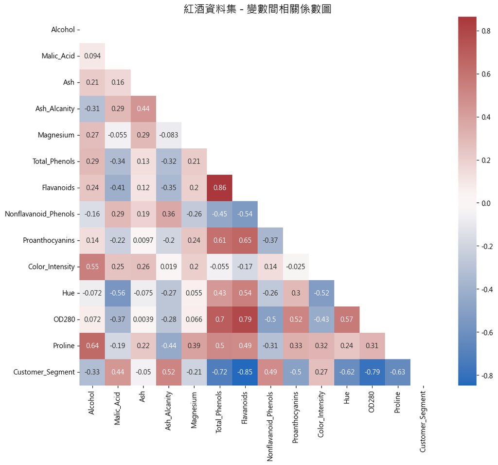

```python
plt.rcParams['font.family'] = 'Microsoft JhengHei'
plt.rcParams['axes.unicode_minus'] = False

df = pd.read_excel(r'D:\machinelearning\HW\HW-data\wine.xlsx')

corr_matrix = df.corr()

plt.figure(figsize=(12, 10))
mask = np.triu(np.ones_like(corr_matrix, dtype=bool))
sns.heatmap(corr_matrix, annot=True, mask=mask, cmap='vlag')

plt.title('紅酒資料集 - 變數間相關係數圖', fontsize=16)

plt.show()
```

觀察與討論

從紅酒資料相關係數圖可觀察到：

> 高度正相關的變數組：

> > Flavanoids 與 Total_Phenols 的相關係數高達 0.86，表示這兩項成分高度相關，可能存在資訊重疊，屬於同一類型的特徵。  
> > Flavanoids 與 OD280 亦呈現高度正相關 (0.79)，顯示這些特徵可能共同反映紅酒的某種特質。

> 高度負相關的變數組：

> > Flavanoids 與 Customer_Segment 的相關係數達到 -0.85，意味著不同顧客群組的紅酒在此成分上的差異非常明顯。  
> > OD280 與 Customer_Segment 的相關係數也高達 -0.79，表明此特徵對不同製造商或客戶分類有明顯的區別能力。

> 一般相關性的觀察：

> > 大多數變數之間的相關係數介於中、低程度，表示大部分變數皆有其獨特性，未形成明顯冗餘。  
> > 部分特徵如 Alcohol 和 Proline (0.64) 呈現中等正相關，可視為某種相似的酒類特性指標。  
> > Malic_Acid 與 Hue 呈現負相關（-0.56），但未達高度負相關標準，仍具參考價值。

> 後續建議：

> > 在後續分析進行特徵選取或降維處理（例如主成分分析，PCA）時，建議優先考量這些高度相關的變數組，避免資訊重複造成分析上的冗餘與多重共線性問題。

3.繪製一張含每個化學成分（變數）的盒鬚圖（Boxplot），觀察每個變數的 scaling，作為是否標準化的參考。

程式碼主要功能

> 使用 Python 中的 StandardScaler 套件，將紅酒資料中的特徵（13種化學成分）進行標準化處理（Standardization），使各變數的數值範圍調整至具有相同尺度（平均數為0、標準差為1）。接著透過 Matplotlib 套件繪製原始資料與標準化後資料的盒鬚圖（Boxplot），以視覺化方式清楚呈現標準化前後各變數尺度的差異，觀察是否存在極端值與資料分佈情形，並進一步判斷後續分析是否需要進行資料標準化處理。

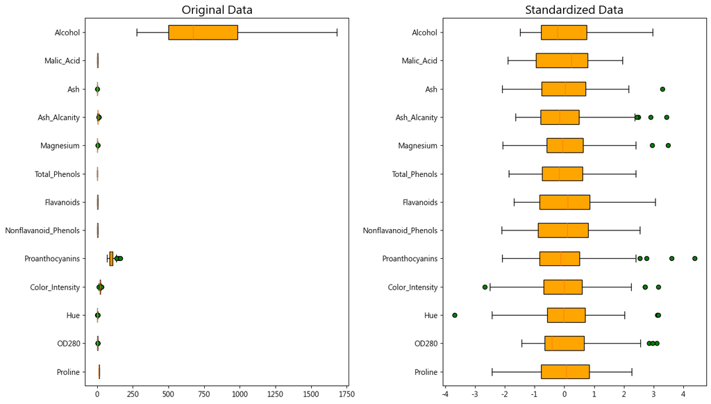

```python
from sklearn.preprocessing import StandardScaler
X = df.drop('Customer_Segment', axis=1)

scaler = StandardScaler()
X_scaled = pd.DataFrame(scaler.fit_transform(X), columns=X.columns)

fig, axes = plt.subplots(ncols=2, figsize=(14, 8))

axes[0].boxplot(X, vert=False, patch_artist=True, boxprops=dict(facecolor='orange', linestyle='--'), flierprops=dict(marker='o', markerfacecolor='green'))
axes[0].set_yticklabels(X.columns[::-1])
axes[0].set_title('Original Data', fontsize=16)

axes[1].boxplot(X_scaled, vert=False, patch_artist=True, boxprops=dict(facecolor='orange', linestyle='--'), flierprops=dict(marker='o', markerfacecolor='green'))
axes[1].set_yticklabels(X_scaled.columns[::-1])
axes[1].set_title('Standardized Data', fontsize=16)

plt.tight_layout()
plt.show()
```

觀察與討論

變數尺度差異與標準化之必要性，根據盒鬚圖的觀察：

> 原始資料（Original Data）：

> 標準化資料（Standardized Data）：

> 結論與後續建議：

> > 建議後續分析（如主成分分析或其他機器學習方法）使用標準化後的資料，以降低不同變數之間尺度差異造成的影響，進而使模型結果更為可靠且具代表性。

4.進行主成分分析，繪製特徵值由大而小的分布與 scree plot。

程式碼主要功能

> 利用主成分分析（PCA）方法，將紅酒資料集的各個化學成分特徵，轉換成主成分（Principal Components），以降低變數的維度，並視覺化主成分的重要性。

主要步驟包含：

> - 資料標準化：將各特徵變數標準化，避免數值尺度差異對 PCA 產生影響。
> - 主成分分析 (PCA)：分析資料的特徵值（Eigenvalues）與主成分的解釋變異比例（Explained Variance Ratio）。
> - 繪製 Scree Plot（特徵值圖）：呈現各主成分的特徵值大小，有助於判斷應保留多少個主成分。
> - 繪製 Pareto Plot（累積解釋變異圖）：呈現主成分的累積解釋變異百分比，協助決定保留幾個主成分才能有效代表原始資料的整體資訊，以利後續分析或模型建立。

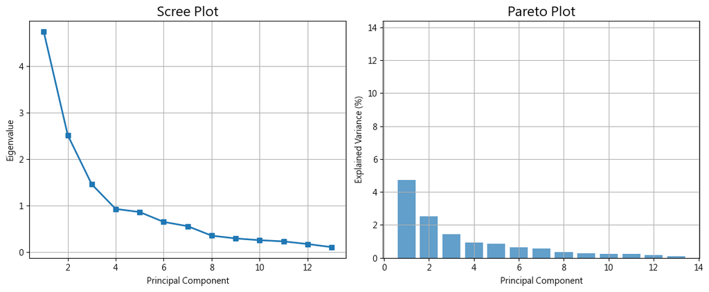

```python
from sklearn.decomposition import PCA
X = df.drop('Customer_Segment', axis=1)

from sklearn.preprocessing import StandardScaler
X_scaled = StandardScaler().fit_transform(X)

pca = PCA()
pca.fit(X_scaled)

eigenvalues = pca.explained_variance_
cum_var_exp = np.cumsum(pca.explained_variance_ratio_) * 100

fig, axes = plt.subplots(ncols=2, figsize=(12, 5))

axes[0].plot(range(1, len(eigenvalues) + 1), eigenvalues, marker='s', linestyle='-', linewidth=2)
axes[0].set_xlabel('Principal Component')
axes[0].set_ylabel('Eigenvalue')
axes[0].set_title('Scree Plot', fontsize=16)
axes[0].grid()

axes[1].bar(range(1, len(eigenvalues) + 1), eigenvalues, alpha=0.7)
axes[1].plot(range(1, len(eigenvalues) + 1), cum_var_exp, 'r-o')
axes[1].set_ylim([0, sum(eigenvalues)*1.1])
axes[1].set_ylabel('Explained Variance (%)')
axes[1].set_title('Pareto Plot', fontsize=16)
axes[1].grid()

for ax in axes:
    ax.set_xlabel('Principal Component')

plt.tight_layout()
plt.show()
```

觀察與討論  
主成分分析 (PCA) 根據 Scree Plot 與 Pareto Plot 可得到以下觀察與結論：

> Scree Plot（特徵值圖）：

> > 主成分的特徵值明顯遞減，尤其在前幾個主成分（1~3）處呈現較為明顯的下降趨勢，表示前幾個主成分解釋了大部分資料的變異。 主成分的特徵值於第四個主成分後逐漸趨於平緩，說明從第四個主成分之後，每個主成分額外貢獻的資訊相對有限。

> Pareto Plot（累積解釋變異百分比）：

> > 第一個主成分的解釋變異明顯最高，達到總變異比例中相當大的部分，顯示此主成分可有效代表資料的主要特徵。 隨著主成分序號增加，個別主成分所解釋的變異數比例逐漸減少，表示後續主成分的重要性與貢獻逐漸下降。

> 結論與後續建議：

> > 若要進一步進行資料分析或建構模型，建議可優先選擇前3至4個主成分作為資料代表，可顯著降低資料維度，同時保留大部分原始資訊。  
> > 利用較少主成分可降低模型的複雜性與多重共線性問題，提高分析效率與結果的穩定性。

5.資料中的每支酒都有標籤（label），代表來自哪個酒莊。假設先不看這項標籤。利用主成分分析取得前兩項成分，並繪製其散布圖。如圖，是否可以從兩個主成分的散布圖中看出三個群組？請注意：資料是否先做標準化可能會影響結果，試著觀察做與不做標準化的差別。

程式碼主要功能

> 透過 Python 中的主成分分析（PCA），比較「未標準化」與「標準化」的資料，在僅使用前兩個主成分的情況下進行視覺化散布圖，以觀察兩者對資料分群效果的影響：
> - 首先將原始資料（未標準化）與經過標準化的資料分別進行 PCA 處理，降維成兩個主成分。
> - 利用散布圖視覺化兩種資料狀態下的分布差異，清楚呈現標準化與未標準化對資料群聚效果的影響。
> - 視覺化結果可作為判斷資料是否需要進行標準化的重要參考，進一步決定最適合後續分析的資料處理方式。

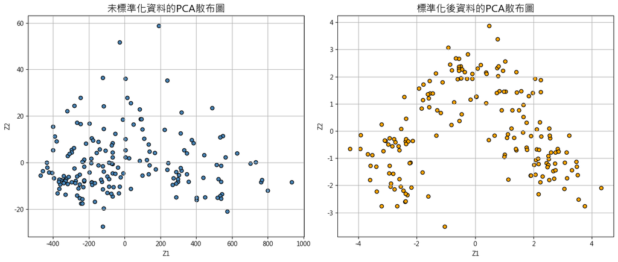

```python
X = df.drop('Customer_Segment', axis=1)

pca = PCA(n_components=2)
X_pca_original = pca.fit_transform(X)

scaler = StandardScaler()
X_scaled = scaler.fit_transform(X)


pca_scaled = PCA(n_components=2)
X_pca_scaled = pca_scaled.fit_transform(X_scaled)

fig, axes = plt.subplots(1, 2, figsize=(14, 6))

axes[0].scatter(X_pca_original[:, 0], X_pca_original[:, 1], c='steelblue', edgecolors='k')
axes[0].set_xlabel('Z1')
axes[0].set_ylabel('Z2')
axes[0].set_title('未標準化資料的PCA散布圖', fontsize=16)
axes[0].grid()

axes[1].scatter(X_pca_scaled[:, 0], X_pca_scaled[:, 1], color='orange', edgecolors='k')
axes[1].set_xlabel('Z1')
axes[1].set_ylabel('Z2')
axes[1].set_title('標準化後資料的PCA散布圖', fontsize=16)
axes[1].grid()

plt.tight_layout()
plt.show()
```

觀察與討論

透過比較主成分分析（PCA）前兩主成分散布圖（未標準化 vs. 標準化），可觀察到：

> 未標準化的 PCA 散布圖（左圖）：

> > 資料點的分布較為集中且模糊，群聚情況不易分辨，整體資料分布趨於混亂。 因特徵之間存在極大的數值差異，可能導致單一或少數數值極大的特徵主導 PCA 結果，影響主成分的區別能力。

> 標準化後的 PCA 散布圖（右圖）：

> > 經過標準化處理，資料點在兩個主成分（Z1 與 Z2）上的分布更為明顯，且分群效果相較未標準化時更加清晰，看出至少三個群聚趨勢。 結果顯示透過標準化處理能有效提升主成分分析對資料的區辨能力。

> 結論與後續建議：

> > 標準化處理對 PCA 分析有顯著幫助，能有效凸顯資料的內在結構與潛在群組。 後續在使用主成分分析或其他統計模型時，應先進行資料標準化，以提高分析結果的準確性與可靠性。

6.再依據每個資料的標籤，為每個在散布圖上的資料點塗上顏色。

程式碼主要功能

> 利用主成分分析（PCA）將原始資料與標準化後資料降維至兩個主成分（Z1、Z2），並將資料根據其所屬標籤（Customer_Segment）進行分群視覺化。透過對比「未標準化」與「標準化後」的 PCA 散布圖，並依據標籤（label 1、label 2、label 3）分別上色，觀察各群資料點在降維後空間中的分布情況，評估資料標準化對於群組可分性的影響與改善程度。圖表有助於以顏色清晰呈現不同 label 資料的潛在結構與分群效果

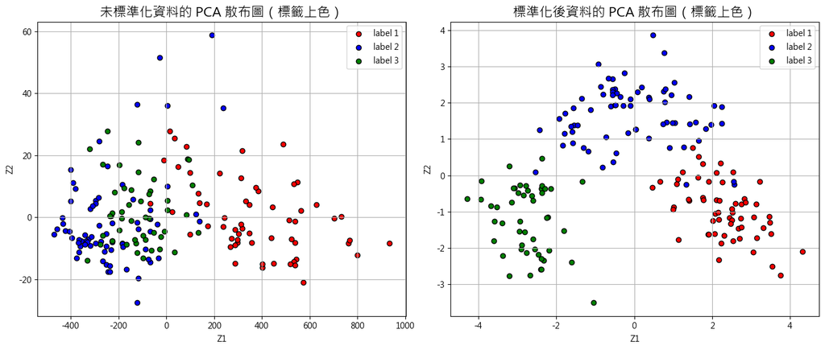

```python
# 特徵變數與標籤
X = df.drop('Customer_Segment', axis=1)
y = df['Customer_Segment']

# PCA (未標準化)
pca = PCA(n_components=2)
X_pca_original = pca.fit_transform(X)

# 資料標準化後 PCA
scaler = StandardScaler()
X_scaled = scaler.fit_transform(X)
pca_scaled = PCA(n_components=2)
X_pca_scaled = pca_scaled.fit_transform(X_scaled)

# 繪圖並根據標籤上色
fig, axes = plt.subplots(1, 2, figsize=(14, 6))

colors = ['red', 'blue', 'green']
labels = ['label 1', 'label 2', 'label 3']

# 未標準化資料散布圖
for label, color in zip(np.unique(y), colors):
    axes[0].scatter(
        X_pca_original[y == label, 0],
        X_pca_original[y == label, 1],
        c=color, label=labels[label-1], edgecolors='k'
    )
axes[0].set_xlabel('Z1')
axes[0].set_ylabel('Z2')
axes[0].set_title('未標準化資料的 PCA 散布圖（標籤上色）', fontsize=16)
axes[0].legend()
axes[0].grid()

# 標準化後資料散布圖
for label, color in zip(np.unique(y), colors):
    axes[1].scatter(
        X_pca_scaled[y == label, 0],
        X_pca_scaled[y == label, 1],
        c=color, label=labels[label-1], edgecolors='k'
    )
axes[1].set_xlabel('Z1')
axes[1].set_ylabel('Z2')
axes[1].set_title('標準化後資料的 PCA 散布圖（標籤上色）', fontsize=16)
axes[1].legend()
axes[1].grid()

plt.tight_layout()
plt.show()
```

觀察與討論

標準化與未標準化 PCA 散布圖的差異，透過比較兩張圖表，可以觀察到明顯差異：

> 未標準化的 PCA 散布圖（左圖）：

> > 三個 label 的分界較模糊，各群資料點相互混雜，不易有效區分群組。 特別是 label 2 與標 label 3 的資料點有明顯重疊現象，顯示未經標準化時，特徵尺度較大者主導了 PCA 分析的結果，導致難以分辨 label 之間的差異。

> 標準化後的 PCA 散布圖（右圖）：

> > 經過標準化處理後的資料點呈現明顯的群聚分布，三個 label 之間的區分非常清晰。 label 1（紅色）、label 2（藍色）與label 3（綠色）的資料點各自形成明顯的群聚，表示資料標準化成功改善了 PCA 的區分能力，並有效揭示 label 間的特徵差異。

> 結論與後續建議：

> > 經過標準化處理的資料更適合進行 PCA 分析，有助於更有效地發掘及區分資料潛在的群組結構。 未來進行主成分分析或其他統計模型時，都應事先考慮進行標準化，以提升分析結果的可解讀性與準確性。

7.如果採三個主成分，則可繪製立體圖。觀察立體圖是否比標準化後的PCA散布圖具備更好的群組分辨能力。請嘗試旋轉立體圖的角度以取得最好的辨別視野。

程式碼主要功能

> 透過標準化後的紅酒資料，使用主成分分析（PCA）將原始的多維資料降維至三個主成分（Z1、Z2、Z3），並依據紅酒標籤（Customer_Segment）在三維空間中進行分群視覺化。程式中一次產出兩個不同角度的 3D 散布圖，以利觀察群組分布與重疊情形，進一步評估三個主成分下的資料分群效果是否優於前一題的 2D 散布圖。這有助於揭示潛在的群組結構，提升資料的解釋性與後續模型的可判別性。

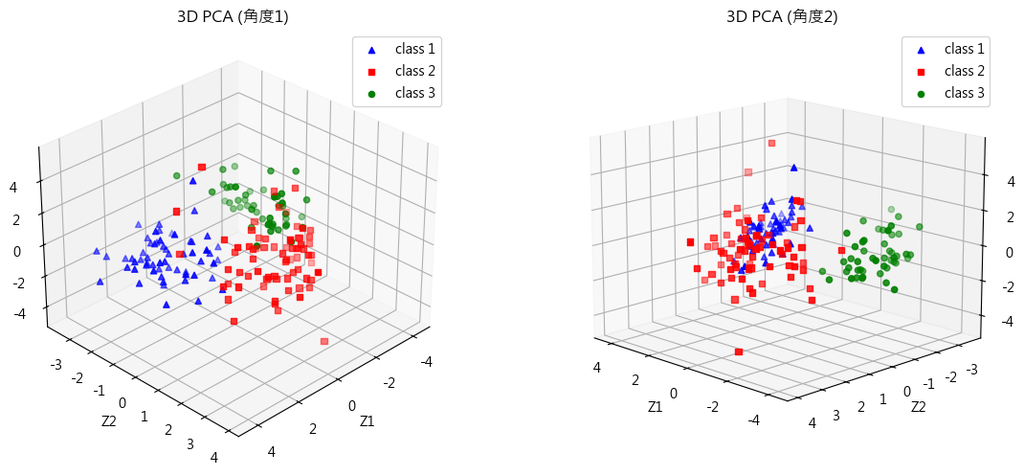

```python
from mpl_toolkits.mplot3d import Axes3D
from sklearn.preprocessing import StandardScaler
from sklearn.decomposition import PCA

X = df.drop('Customer_Segment', axis=1)
y = df['Customer_Segment']

scaler = StandardScaler()
X_scaled = scaler.fit_transform(X)

pca_3d = PCA(n_components=3)
X_pca_3d = pca_3d.fit_transform(X_scaled)

colors = ['blue', 'red', 'green']
labels = ['class 1', 'class 2', 'class 3']
markers = ['^', 's', 'o']

fig = plt.figure(figsize=(12, 5))

ax1 = fig.add_subplot(1, 2, 1, projection='3d')
for label, color, marker in zip(np.unique(y), colors, markers):
    ax1.scatter(
        X_pca_3d[y == label, 0],
        X_pca_3d[y == label, 1],
        X_pca_3d[y == label, 2],
        c=color, marker=marker, label=labels[label-1]
    )
ax1.view_init(elev=30, azim=45)
ax1.set_xlabel('Z1')
ax1.set_ylabel('Z2')
ax1.set_zlabel('Z3')
ax1.set_title('3D PCA (角度1)')
ax1.legend()

ax2 = fig.add_subplot(1, 2, 2, projection='3d')
for label, color, marker in zip(np.unique(y), colors, markers):
    ax2.scatter(
        X_pca_3d[y == label, 0],
        X_pca_3d[y == label, 1],
        X_pca_3d[y == label, 2],
        c=color, marker=marker, label=labels[label-1]
    )
ax2.view_init(elev=15, azim=135)
ax2.set_xlabel('Z1')
ax2.set_ylabel('Z2')
ax2.set_zlabel('Z3')
ax2.set_title('3D PCA (角度2)')
ax2.legend()

plt.tight_layout()
plt.show()
```

觀察與討論

透過三個主成分 (Z1、Z2、Z3) 將紅酒資料投影到三維空間中，並分別從兩個不同視角進行觀察，結果如下：

> 第一視角（左圖，角度1）

> > 從此視角下觀察，可初步辨識出三個群組的分佈特徵。  
> > label 1（藍色）、label 2（紅色）與 label 3（綠色）各自形成明顯的分群，尤其 label 1 和 label 3 之間的區隔較為明確。

> 第二視角（右圖，角度2）

> 結論與後續建議：

> > 使用三個主成分進行 3D PCA，確實比前一題的 2D PCA 更具分群辨識效果，尤其在不同視角的輔助下，資料的空間分布與群組間的區隔性變得更為明顯。  
> > 這顯示第三主成分 (Z3) 提供了額外的資訊，有助於強化對不同紅酒樣本的可區分性。  
> > 後續進行機器學習建模，建議可考慮保留前三個主成分，以保留較高的變異資訊，並提高模型的群組辨識能力與解釋性。

8.Z1 與 Z2 都是從原變數組合而成的新變數，可否從 Z1 與 Z2 的組成係數（即前兩個 eigenvector 的值），看出原變數哪個比較重要？哪個比較不重要？若再與原變數間的相關係數圖對照，是否透露相同的訊息。先不管理論怎麼說，就只是談談你的觀察與猜測。（譬如可以畫 eigenvectors 與變數對應的 heatmap）。

程式碼主要功能

> 將前兩個主成分（Z1 與 Z2）對原始變數的組成係數（即 eigenvectors）視覺化為熱圖。先移除標籤欄位後進行標準化處理，接著使用 PCA 提取前兩個主成分，最後將這些主成分與原變數之間的線性組合係數以熱圖呈現。此圖有助於判斷哪些原始變數對 Z1 與 Z2 的貢獻較大，並可進一步用來解釋 PCA 所反映出的潛在結構。

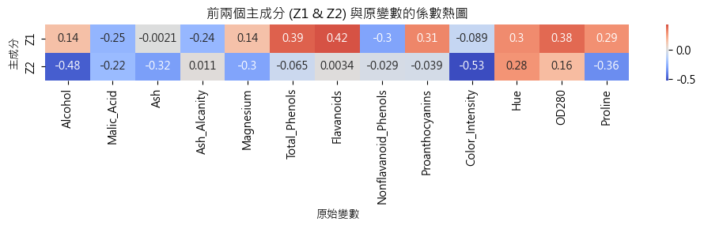

```python
X = df.drop('Customer_Segment', axis=1)
scaler = StandardScaler()
X_scaled = scaler.fit_transform(X)

pca = PCA(n_components=2)
pca.fit(X_scaled)

eigenvectors = pd.DataFrame(
    pca.components_,
    columns=X.columns,
    index=['Z1', 'Z2']
)

plt.figure(figsize=(10, 3))
sns.heatmap(eigenvectors, annot=True, cmap='coolwarm', center=0)
plt.title('前兩個主成分 (Z1 & Z2) 與原變數的係數熱圖')
plt.xlabel('原始變數')
plt.ylabel('主成分')
plt.tight_layout()
plt.show()
```

觀察與討論

從熱圖中可以看出，Z1 和 Z2 是由不同原始變數以不同程度的線性組合所構成的主成分。

> Z1 組成觀察：

> Z2 組成觀察：

> > Z2 中，Alcohol（-0.48） 和 Color_Intensity（-0.53） 的負係數特別顯著，代表這兩個變數在 Z2 中有較強的負向影響。  
> > 另外，Hue（0.28） 和 OD280（0.16） 則對 Z2 有正向貢獻。

> 與原始變數相關係數對照：

> > 若與前面繪製的相關係數熱圖對照，發現 Z1 的高貢獻變數（如 Flavanoids、Total_Phenols、OD280）之間原本就有中高度的正相關，這與 PCA 結果一致，顯示這些變數攜帶著相似的資訊，PCA 將其整合進 Z1。  
> > Z2 則似乎從原本與 Z1 不同的變數（如 Alcohol、Color_Intensity）中擷取資訊，形成另一個解釋方向。

> 結論：

> > Z1 較多反映出紅酒中的酚類濃度與品質指標，而 Z2 則更多與酒精濃度與色澤表現相關。  
> > 這樣的觀察有助於後續在解讀主成分時，將 Z1 與「成分濃度」類變數聯想在一起，Z2 則與「酒精、顏色」相關特徵連結。

**第 二 題：**

**回答類似習題 1 的問題（如下所述），資料來自 NUMBEO 的 Quality of Life Index by City 2025 （下載 2025_city_quality.xlsx）關於世界 263 個城市的生活品質排名，其中包含 8 個指標數字。在此可以將排名資料置換成代表生活品質的「標籤 labels」，譬如總分數（欄位 Quality of Life Index）200 分以上稱為「高品質」或「HIGH」，並配與數字 3；分數 100 ~200 稱為「中品質」或「MEDIUM」，並配與數字 2；總分 100 以下稱為「低品質」或「LOW」，並配與數字 1。當然這種分組方式可以自訂，譬如分四組或五組，再看看進行 PCA 後的表現。**  
(資料來源：2025_city_quality.xlsx)

1.觀察資料。譬如利用 pandas 的 head() 指令呈現前面幾筆資料。

程式碼主要功能

> 讀取指定路徑下的「2025_city_quality.xlsx」資料檔，並進行資料初步檢查。利用 pandas 的 read_excel 函數將 Excel 資料讀入為 DataFrame（df1），接著使用 head() 顯示前五筆資料，快速觀察欄位名稱與部分數值內容。透過 shape 屬性印出資料集的總筆數與欄位數，並使用 isnull().sum().sum() 統計整體資料集中的遺漏值數量，確認資料的完整性與品質，作為後續資料處理與分析的基礎。

```python
df1 = pd.read_excel(r'D:\machinelearning\HW\HW-data\2025_city_quality.xlsx')

print(df1.head())

print(f"資料筆數與特徵數量：{df1.shape}")

print(f"遺漏值數量：{df1.isnull().sum().sum()}")
```

```
   Rank                               City  Quality of Life Index  \
0     1  The Hague (Den Haag), Netherlands                  229.0
1     2             Groningen, Netherlands                  225.9
2     3             Luxembourg, Luxembourg                  219.9
3     4             Eindhoven, Netherlands                  218.3
4     5                 Basel, Switzerland                  217.0

   Purchasing Power Index  Safety Index  Health Care Index  \
0                   151.8          79.5               80.7
1                   153.5          78.1               76.4
2                   174.4          71.3               76.3
3                   140.6          78.4               79.0
4                   182.4          72.9               71.6

   Cost of Living Index  Property Price to Income Ratio  \
0                  58.3                             5.7
1                  54.5                             5.0
2                  66.0                             8.8
3                  59.9                             6.4
4                  98.0                             8.5

   Traffic Commute Time Index  Pollution Index  Climate Index
0                        21.0             17.9           90.6
1                        20.1             18.8           83.5
2                        27.5             21.6           82.6
3                        24.0             19.2           85.4
4                        27.6             24.9           82.8
資料筆數與特徵數量：(263, 11)
遺漏值數量：0
```

觀察與討論

透過 head() 函數與基本資料檢查，可得以下觀察結果：

> 資料結構與筆數

> > 資料集中包含 263 筆資料與 11 個欄位（含 Rank 與 City 資訊），每一筆資料代表一個城市，並記錄了該城市的生活品質指標。

> 欄位內容

除了城市名稱與排名（Rank、City）之外，其餘欄位皆為數值型指標，包含：

> - Quality of Life Index
> - Purchasing Power Index
> - Safety Index
> - Health Care Index
> - Cost of Living Index
> - Property Price to Income Ratio
> - Traffic Commute Time Index
> - Pollution Index
> - Climate Index

> 資料完整性

> > 從結果顯示，資料中「遺漏值數量為 0」，代表所有欄位的數據都完整，無需進行額外的缺失值處理。

> 變數特徵

> > 各指標的數值範圍差異明顯，例如：
> - Property Price to Income Ratio 普遍落在 5 到 10 左右。
> - Traffic Commute Time Index 和 Pollution Index 數值則偏低。
> - 而 Quality of Life Index 數值相對較高（通常超過 100）。

> 結論

> > 資料適合作為進行 PCA 分析的資料集，且因為各欄位指標的尺度相差較大（如 Property Price 與 Quality of Life 指數量級不同），未來進行主成分分析（PCA）時，建議先進行標準化處理，以避免尺度影響解釋變異量的結果。

2.繪製變數間的相關係數圖，以觀察變數間是否存在相關性（參考上題的圖或其他類似的圖）。

程式碼主要功能

> 計算並可視化資料集中各指標變數間的相關係數矩陣。先排除不具分析意義的欄位（如排名與城市名稱），接著利用 pandas 計算剩餘指標變數之間的皮爾森相關係數，並使用 seaborn 繪製出下三角的熱力圖（heatmap），透過色彩深淺區分正負相關及強弱程度，協助使用者快速辨識變數間的線性關聯性，並為後續進行特徵選擇或降維分析（如 PCA）提供參考依據。

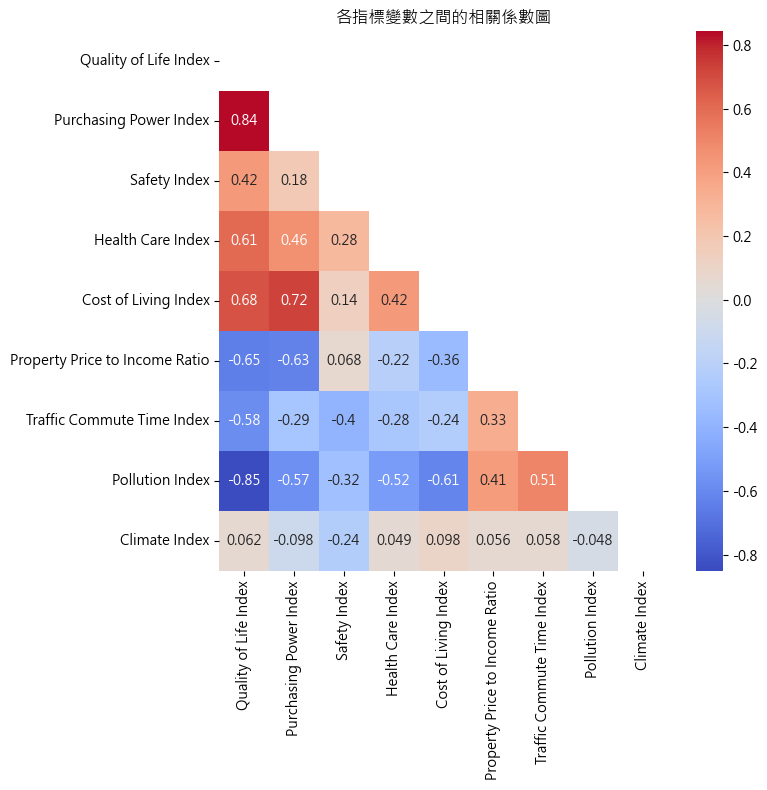

```python
corr_features = df1.drop(['Rank', 'City'], axis=1)

corr_matrix = corr_features.corr()

plt.figure(figsize=(8, 8))
mask = np.triu(np.ones_like(corr_matrix, dtype=bool))
sns.heatmap(corr_matrix, annot=True, mask=mask, cmap='coolwarm', center=0)

plt.title('各指標變數之間的相關係數圖')
plt.tight_layout()
plt.show()
```

觀察與討論

從資料相關係數圖可觀察到：

> 高度正相關的變數組：

> > Quality of Life Index 與 Purchasing Power Index（0.84）呈現高度正相關，顯示購買力強的城市往往生活品質也較高。  
> > Quality of Life Index 與 Cost of Living Index（0.68）及 Health Care Index（0.61）也有中等以上的正相關，顯示高生活成本及良好的醫療體系，可能與生活品質有正向關聯。  
> > Purchasing Power Index 與 Cost of Living Index（0.72）正相關，顯示高購買力地區通常生活成本也較高。

> 高度負相關的變數組：

> > Quality of Life Index 與 Pollution Index（-0.85）有強烈負相關，符合直覺，即污染嚴重的城市生活品質較低。  
> > Property Price to Income Ratio 與 Purchasing Power Index（-0.63）呈現負相關，說明購買力高的城市房價相對收入比值較低。  
> > Traffic Commute Time Index 與 Quality of Life Index（-0.58）呈負相關，通勤時間越長的城市生活品質傾向較差。

> 一般相關性的觀察：

> > Climate Index 與其他變數的相關性皆不高（接近 0），顯示氣候舒適度較獨立於其他經濟或生活指標，未與特定指標呈現明顯正負關係。

> 結論：

> > 本圖顯示多數經濟或基礎設施指標與生活品質呈現一定程度的正向關係，而污染、房價壓力與通勤時間則與生活品質呈負相關，符合一般對於高品質生活的直觀印象。這些發現將助於後續進一步探討各指標在主成分分析中的影響力 。

3.繪製一張含每個量測變數的盒鬚圖（Boxplot），觀察每個變數的 scaling，作為是否標準化的參考（如上題繪製的兩張 Boxplot 圖, 一張針對原始資料，另一張則是標準化後的資料）。

程式碼主要功能

讀取 2025_city_quality 資料集，並針對資料中的各個量測變數（例如購買力指數、醫療指數、氣候指數等）進行視覺化比較。具體步驟如下：

> 資料載入與前處理：

> > 從指定路徑讀取 Excel 格式的資料集，並移除非數值欄位（Rank 與 City），僅保留數值型特徵。

> 資料標準化：

> > 使用 StandardScaler 對特徵進行 Z-score 標準化，使每個變數的平均值為 0，標準差為 1，解決變數尺度不一致的問題。

> 資料視覺化：

> > 繪製兩張 boxplot 圖：
> > - 左圖顯示原始資料的 boxplot，可觀察到變數間的數值範圍差異。
> > - 右圖顯示標準化後的 boxplot，呈現經過標準化後變數分佈的一致性。

幫助使用者判斷是否有必要對資料進行標準化處理

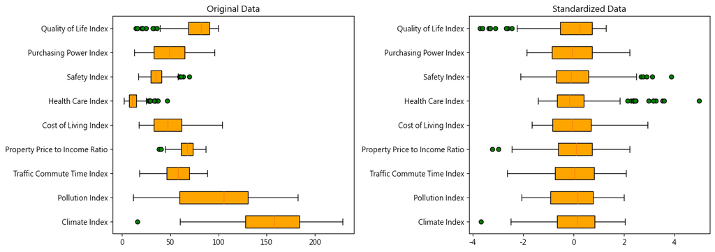

```python
df1 = pd.read_excel(r'D:\machinelearning\HW\HW-data\2025_city_quality.xlsx')

features = df1.drop(['Rank', 'City'], axis=1)

scaler = StandardScaler()
features_scaled = pd.DataFrame(scaler.fit_transform(features), columns=features.columns)

fig, axes = plt.subplots(1, 2, figsize=(14, 5))

axes[0].boxplot(features, vert=False, patch_artist=True, boxprops=dict(facecolor='orange', linestyle='--'), flierprops=dict(marker='o', markerfacecolor='green'))
axes[0].set_yticklabels(features.columns[::-1])
axes[0].set_title('Original Data')

axes[1].boxplot(features_scaled, vert=False, patch_artist=True, boxprops=dict(facecolor='orange', linestyle='--'), flierprops=dict(marker='o', markerfacecolor='green'))
axes[1].set_yticklabels(features_scaled.columns[::-1])
axes[1].set_title('Standardized Data')

plt.tight_layout()
plt.show()
```

觀察與討論

從上述 boxplot 可明顯觀察到資料在標準化前與標準化後的差異：

> 原始資料（左圖）：

> 標準化後資料（右圖）：

> > 所有變數經過標準化後，其分佈的尺度被統一，盒鬚圖的範圍基本上集中在 0 附近，變數間的尺度差距消失。  
> > 雖然離群值仍然存在，但整體變數分佈趨於一致，這有利於後續進行 PCA、機器學習等分析時，讓每個變數具有相同的重要性與解釋力。

> 結論：

> > 標準化是進行多變數分析的重要步驟，尤其是當原始資料中的變數尺度落差極大時。從圖中可以清楚看出，未標準化的資料會導致部分指標被放大或主導後續分析，進行標準化能有效避免此問題，使各變數在分析中具備相同權重，提升模型表現與解釋力。

4.進行主成分分析，繪製特徵值由大而小的分佈，如 scree plot 與累積百分比的 pareto plot。

程式碼主要功能

> 進行主成分分析（PCA）並視覺化結果。刪除「Rank」與「City」兩個非數值欄位後，對剩餘的數值特徵進行標準化處理（Standardization）。接著，利用 PCA 將資料轉換為一組無相關的新變數，並計算各主成分的特徵值（eigenvalues）與累積解釋變異百分比（cumulative variance explained）。

> 透過兩張圖表呈現結果：左圖為 Scree Plot，展示各主成分的特徵值變化，右圖為 Pareto Plot，顯示主成分的特徵值分布及累積解釋變異百分比，用於判斷適合保留的主成分數量。

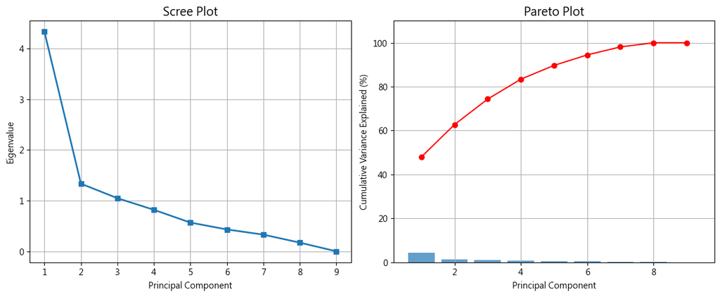

```python
df1 = pd.read_excel(r'D:\machinelearning\HW\HW-data\2025_city_quality.xlsx')

features = df1.drop(['Rank', 'City'], axis=1)

scaler = StandardScaler()
features_scaled = scaler.fit_transform(features)

pca = PCA()
pca.fit(features_scaled)

eigenvalues = pca.explained_variance_
cumulative_variance = np.cumsum(pca.explained_variance_ratio_) * 100

fig, axes = plt.subplots(1, 2, figsize=(12, 5))

axes[0].plot(range(1, len(eigenvalues) + 1), eigenvalues, marker='s', linestyle='-', linewidth=2)
axes[0].set_xlabel('Principal Component')
axes[0].set_ylabel('Eigenvalue')
axes[0].set_title('Scree Plot', fontsize=14)
axes[0].grid()

axes[1].bar(range(1, len(eigenvalues) + 1), eigenvalues, alpha=0.7)
axes[1].plot(range(1, len(cumulative_variance) + 1), cumulative_variance, 'r-o')
axes[1].set_ylabel('Cumulative Variance Explained (%)')
axes[1].set_xlabel('Principal Component')
axes[1].set_ylim([0, max(cumulative_variance) * 1.1])
axes[1].set_title('Pareto Plot', fontsize=14)
axes[1].grid()

plt.tight_layout()
plt.show()
```

觀察與討論

> 左圖的 Scree Plot

> 右圖的 Pareto Plot

> 結論：

> > 可考慮後續分析時僅保留前 2 至 3 個主成分，進行降維處理，同時能有效保留資料的主要特徵，達成資料簡化與維持資訊量的平衡。

5.每筆資料都有標籤值（label），代表生活品質的高低（3: HIGH, 2:MEDIUM, 1:LOW）。假設先不看這項標籤。利用主成分分析取得前兩項成分（Z_1 與 Z_2），並繪製其散佈圖。是否可以從兩個主成分的散佈圖中看出兩個群組？請注意：資料是否先做標準化可能會影響結果，試著觀察「做與不做」標準化的差別。

程式碼主要功能

針對 2025_city_quality 資料，進行主成分分析（PCA）並繪製資料投影於前兩個主成分（Z1 和 Z2）的散佈圖。程式分為以下幾個步驟：

> 未標準化資料的 PCA：

> > 對原始資料（未標準化）進行 PCA，萃取前兩個主成分，並儲存轉換後的結果。

> 標準化資料的 PCA：

> > 使用 StandardScaler 對資料進行標準化處理，再進行 PCA，並同樣擷取前兩個主成分。

> 繪製散佈圖：

> > 產生兩張散佈圖，分別呈現未標準化與標準化後資料在 Z1 與 Z2 平面上的分佈情況，用以比較標準化對資料分佈的影響，並觀察資料是否呈現潛在的群聚特徵。

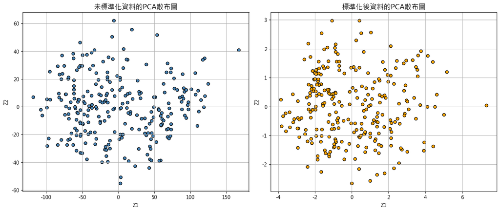

```python
df1 = pd.read_excel(r'D:\machinelearning\HW\HW-data\2025_city_quality.xlsx')

df1['label'] = pd.cut(df1['Quality of Life Index'], bins=[-np.inf, 100, 200, np.inf], labels=[1, 2, 3])

X = df1.drop(['Rank', 'City', 'label'], axis=1)

pca = PCA(n_components=2)
X_pca_original = pca.fit_transform(X)

scaler = StandardScaler()
X_scaled = scaler.fit_transform(X)

pca_scaled = PCA(n_components=2)
X_pca_scaled = pca_scaled.fit_transform(X_scaled)

fig, axes = plt.subplots(1, 2, figsize=(14, 6))

axes[0].scatter(X_pca_original[:, 0], X_pca_original[:, 1], c='steelblue', edgecolors='k')
axes[0].set_xlabel('Z1')
axes[0].set_ylabel('Z2')
axes[0].set_title('未標準化資料的PCA散布圖', fontsize=14)
axes[0].grid()

axes[1].scatter(X_pca_scaled[:, 0], X_pca_scaled[:, 1], color='orange', edgecolors='k')
axes[1].set_xlabel('Z1')
axes[1].set_ylabel('Z2')
axes[1].set_title('標準化後資料的PCA散布圖', fontsize=14)
axes[1].grid()

plt.tight_layout()
plt.show()
```

觀察與討論

從上圖的兩張散佈圖中可觀察到以下幾點：

> 未標準化資料的 PCA 散佈圖（左圖）：

> > 資料點分佈較為分散，特別是在 Z1 軸上，數值範圍明顯拉得較大（如 Z1 超過 100 的資料點）。  
> > 這代表未標準化的變數中，有變數的尺度或單位較大，主導了主成分的變異，導致投影結果失去各變數之間的平衡，影響了資料的結構與可視化效果。

> 標準化後資料的 PCA 散佈圖（右圖）：

> > 標準化後的資料分佈變得更加集中與平衡，Z1 和 Z2 軸上的尺度接近，資料點呈現較明顯的橢圓或圓形結構，顯示變數間的影響已被調整至相同的尺度。  
> > 資料分佈呈現出某些隱含的群聚特性，雖然不完全明顯，但比未標準化情況下更容易辨識資料的整體分佈情形。

> 結論：

> > PCA 在未標準化的情況下，易受到原始變數尺度差異的影響，導致部分變數對主成分的主導性過強，讓投影圖失衡；而在標準化後，資料分佈更能反映變數間的真實關係，因此標準化在進行 PCA 前是有必要的，有助於改善解釋變異與可視化效果。

6.再依據每筆資料的標籤（可以配以適當的文字，譬如 3 配置 HIGH），在散佈圖上塗上不同顏色（參考上題的圖）。

程式碼主要功能

針對 2025_city_quality 資料，進行主成分分析（PCA）並繪製資料投影於前兩個主成分（Z1 和 Z2）的散佈圖。程式分為以下幾個步驟：

> 資料前處理：

> > 讀取 2025 年世界城市生活品質資料，依據 Quality of Life Index 分成三個標籤（LOW、MEDIUM、HIGH），並新增至資料框中作為分類依據。

> PCA 分析：

> > 對原始資料（未標準化）進行主成分分析 (PCA)，並提取前兩個主成分（Z1 與 Z2）。 對資料進行標準化處理後，再次進行 PCA，取得標準化後的前兩個主成分。

> 視覺化：

> > 繪製兩張散佈圖：
> > - 左圖為未標準化資料的 PCA 結果。
> > - 右圖為標準化後資料的 PCA 結果。

> 依據標籤（LOW、MEDIUM、HIGH）分別以紅色、藍色、綠色上色，方便觀察群組分佈情形。

> 比較資料在「未標準化」與「標準化」兩種情況下，PCA 降維後的分佈差異，並觀察生活品質分群（LOW、MEDIUM、HIGH）的可分性。

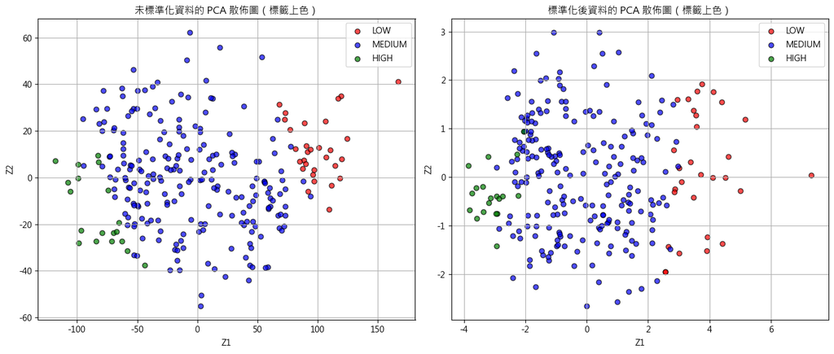

```python
df1 = pd.read_excel(r'D:\machinelearning\HW\HW-data\2025_city_quality.xlsx')

df1['label'] = pd.cut(df1['Quality of Life Index'], bins=[-np.inf, 100, 200, np.inf], labels=[1, 2, 3])

X = df1.drop(['Rank', 'City', 'label'], axis=1)
y = df1['label'].astype(int)

pca = PCA(n_components=2)
X_pca_original = pca.fit_transform(X)

scaler = StandardScaler()
X_scaled = scaler.fit_transform(X)
pca_scaled = PCA(n_components=2)
X_pca_scaled = pca_scaled.fit_transform(X_scaled)


colors = {1: 'red', 2: 'blue', 3: 'green'}
labels_dict = {1: 'LOW', 2: 'MEDIUM', 3: 'HIGH'}

fig, axes = plt.subplots(1, 2, figsize=(14, 6))

for label in [1, 2, 3]:
    axes[0].scatter(
        X_pca_original[y == label, 0],
        X_pca_original[y == label, 1],
        c=colors[label],
        label=labels_dict[label],
        edgecolors='k',
        alpha=0.7
    )
axes[0].set_xlabel('Z1')
axes[0].set_ylabel('Z2')
axes[0].set_title('未標準化資料的 PCA 散佈圖（標籤上色）')
axes[0].legend()
axes[0].grid(True)

for label in [1, 2, 3]:
    axes[1].scatter(
        X_pca_scaled[y == label, 0],
        X_pca_scaled[y == label, 1],
        c=colors[label],
        label=labels_dict[label],
        edgecolors='k',
        alpha=0.7
    )
axes[1].set_xlabel('Z1')
axes[1].set_ylabel('Z2')
axes[1].set_title('標準化後資料的 PCA 散佈圖（標籤上色）')
axes[1].legend()
axes[1].grid(True)

plt.tight_layout()
plt.show()
```

觀察與討論

從兩張散佈圖可以發現，無論是 未標準化 還是 標準化後 的資料，資料點依據生活品質的標籤（LOW、MEDIUM、HIGH）大致上無法清楚地分成明顯的三個群組，但仍有以下現象：

> 未標準化的散佈圖（左圖）：

> > 資料呈現明顯的伸展現象，部分變數的尺度較大，導致 PCA 主要成分受到大尺度變數的強烈影響，資料分佈不均衡。  
> > 三種標籤的資料點分佈混雜，沒有明顯的分群輪廓，尤其 MEDIUM（藍色）幾乎分佈在整個圖中。

> 標標準化後的散佈圖（右圖）：

> > 資料分佈較為集中，並且變數尺度被統一化後，資料在 Z1 與 Z2 空間中的擴散性下降，呈現較均勻的分佈。  
> > 標籤 （HIGH，綠色）與標籤 （LOW，紅色）與標籤 （MEDIUM，藍色）有部分區域上的分離，例如 HIGH 偏向 Z1 負向區域，但整體仍然呈現部分重疊現象。

> 結論：

> > 標準化後的 PCA 散佈圖比未標準化的圖表現更均衡，能較好地觀察標籤間的分佈差異，但從 Z1 與 Z2 的組合中，群組之間的邊界仍不明顯，顯示該資料的前兩個主成分尚無法完全分離生活品質的不同層級。

7.從 Z_1 與 Z_2 的散佈圖進一步推敲，也許需要加入 Z_3 才能分得更好，又或許去除 Z_2 僅取 Z_1 也可以分得不錯。請提出你的看法。

程式碼主要功能

進行資料的標準化與主成分分析（PCA），並透過不同維度的視覺化，觀察生活品質標籤（LOW、MEDIUM、HIGH）在降維後的分佈情況。

> 資料標準化與 PCA 降維：

> > 使用 StandardScaler() 對特徵進行標準化處理。  
> > 使用 PCA(n_components=3) 將資料降至前三個主成分（Z1、Z2、Z3）。

> 三種視覺化圖表：

> > 僅使用 Z1：展示 Z1 對不同標籤的分布情況（以 y=0 為基準線繪製）。  
> > Z1 vs Z2：繪製 Z1 與 Z2 平面下的散佈圖，觀察標籤之間的分群狀況。  
> > Z1 vs Z2 vs Z3（3D）：建立三維散佈圖，進一步檢視三個主成分下的分群效果。

> 標籤上色與圖例：

> > 根據標籤（LOW、MEDIUM、HIGH）為資料點上色（紅、藍、綠），幫助觀察各標籤在不同維度下的分布與聚集情況。  
> > 使用 plt.tight_layout() 確保三張子圖排列整齊，便於比較分析。

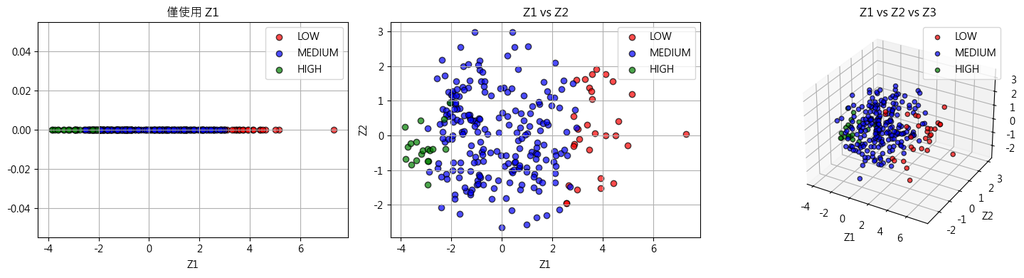

```python
df1 = pd.read_excel(r'D:\machinelearning\HW\HW-data\2025_city_quality.xlsx')

df1['label'] = pd.cut(df1['Quality of Life Index'], bins=[-np.inf, 100, 200, np.inf], labels=[1, 2, 3])

X = df1.drop(['Rank', 'City', 'label'], axis=1)
y = df1['label'].astype(int)

scaler = StandardScaler()
X_scaled = scaler.fit_transform(X)

pca = PCA(n_components=3)
X_pca = pca.fit_transform(X_scaled)

colors = {1: 'red', 2: 'blue', 3: 'green'}
labels_dict = {1: 'LOW', 2: 'MEDIUM', 3: 'HIGH'}

fig = plt.figure(figsize=(15, 4))

ax1 = fig.add_subplot(1, 3, 1)
for label in [1, 2, 3]:
    ax1.scatter(
        X_pca[y == label, 0],
        [0]*sum(y == label),
        c=colors[label],
        label=labels_dict[label],
        edgecolors='k',
        alpha=0.7
    )
ax1.set_xlabel('Z1')
ax1.set_title('僅使用 Z1')
ax1.legend()
ax1.grid(True)

ax2 = fig.add_subplot(1, 3, 2)
for label in [1, 2, 3]:
    ax2.scatter(
        X_pca[y == label, 0],
        X_pca[y == label, 1],
        c=colors[label],
        label=labels_dict[label],
        edgecolors='k',
        alpha=0.7
    )
ax2.set_xlabel('Z1')
ax2.set_ylabel('Z2')
ax2.set_title('Z1 vs Z2')
ax2.legend()
ax2.grid(True)

ax3 = fig.add_subplot(1, 3, 3, projection='3d')
for label in [1, 2, 3]:
    ax3.scatter(
        X_pca[y == label, 0],
        X_pca[y == label, 1],
        X_pca[y == label, 2],
        c=colors[label],
        label=labels_dict[label],
        edgecolors='k',
        alpha=0.7
    )
ax3.set_xlabel('Z1')
ax3.set_ylabel('Z2')
ax3.set_zlabel('Z3')
ax3.set_title('Z1 vs Z2 vs Z3')
ax3.legend()

plt.tight_layout()
plt.show()
```

觀察與討論

從以上三張圖的比較可以看出不同主成分組合下的分群效果差異：

> 僅使用 Z1：

> Z1 vs Z2：

> > 加入 Z2 維度後，資料在平面上略微展開，部分 LOW 和 HIGH 群體在 Z1-Z2 空間內出現些微的分隔。MEDIUM 類別仍然與其他兩類有所重疊，分群仍然不理想。

> Z1 vs Z2 vs Z3（3D）：

> 結論

8.Z_1 與 Z_2 都是從原變數組合而成的新變數，可否從 Z_1 與 Z_2 的組成係數（即前兩個 eigenvector 的值），看出原變數哪個比較重要？哪個比較不重要？若再與原變數間的相關係數圖對照，是否透露相同的訊息。先不管理論怎麼說，就只是談談你的觀察與猜測。（譬如可以畫 eigenvectors 與變數對應的 heatmap)

程式碼主要功能

使用主成分分析（PCA）對標準化後的城市生活品質資料進行降維，提取前兩個主成分（Z1 和 Z2），並以熱圖（heatmap）的方式視覺化主成分與原始變數之間的線性組成係數（即 eigenvectors）：

> 讀取 2025_city_quality.xlsx 資料集，並移除不需要的欄位（Rank 與 City）。  
> 對數據進行標準化處理（StandardScaler），使各變數具有相同的尺度。  
> 執行 PCA，萃取前兩個主成分，並取得主成分在各原始變數上的線性組成權重（eigenvectors）。  
> 使用 seaborn 的 heatmap 繪製主成分與變數之間係數的熱圖，方便觀察各變數在 Z1 和 Z2 上的重要性與正負貢獻。

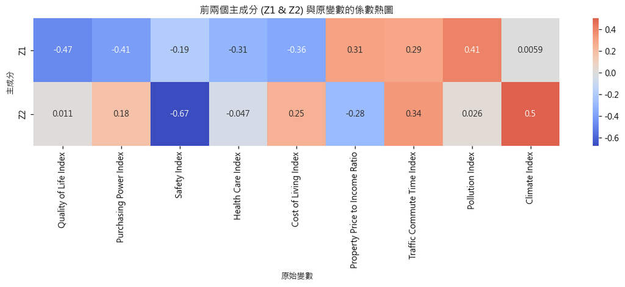

```python
df1 = pd.read_excel(r'D:\machinelearning\HW\HW-data\2025_city_quality.xlsx')
features = df1.drop(['Rank', 'City'], axis=1)

scaler = StandardScaler()
features_scaled = scaler.fit_transform(features)

pca = PCA(n_components=2)
pca.fit(features_scaled)

eigenvectors = pd.DataFrame(
    pca.components_,
    columns=features.columns,
    index=['Z1', 'Z2']
)

plt.figure(figsize=(12, 5))
sns.heatmap(eigenvectors, annot=True, cmap='coolwarm', center=0)
plt.title('前兩個主成分 (Z1 & Z2) 與原變數的係數熱圖')
plt.xlabel('原始變數')
plt.ylabel('主成分')
plt.tight_layout()
plt.show()
```

觀察與討論

從上圖顯示的前兩個主成分（Z1 與 Z2）與原始變數之間的係數熱圖中，觀察到以下幾點：

> Z1 的組成特徵：

> Z2 的組成特徵：

> > Z2 對於 Safety Index (-0.67) 和 Property Price to Income Ratio (-0.28) 呈現較高的負向係數。  
> > 對 Climate Index (0.50) 和 Traffic Commute Time Index (0.34) 則為正向，尤其 Climate Index 是 Z2 中貢獻最高的變數。

> 初步結論：
> > - 重要變數：從 Z1 與 Z2 的係數可以看出，Pollution Index 和 Climate Index 是在前兩個主成分中相對較為重要的變數，因為這些變數在至少一個主成分中具有較高的絕對係數。
> > - 不太重要的變數：

> > 例如 Health Care Index 在兩個主成分中的絕對值皆較小 (-0.31 與 -0.047)，因此可視為相對不重要的變數。

> 與相關係數圖對照：

> > 若將這些結果與前面繪製的原變數相關係數圖比較，會發現具有高度相關性的變數（例如 Purchasing Power Index 與 Quality of Life Index）在主成分中的權重方向類似（皆為負向），這與 PCA 將相關變數合併的特性相符。

**第 三 題：**

**資料則是同樣來自 sklearn.datasets 的一組關於乳癌患者腫瘤的影像量測資料。量測變數共 30 個，樣本數為 569 位患者，區分為兩個群組，分別是 Malignant（惡性腫瘤）與 Benign（良性腫瘤）。**  
(資料來源：[sklearn.datasets](https://scikit-learn.org/stable/modules/generated/sklearn.datasets.load_breast_cancer.html#sklearn.datasets.load_breast_cancer))

1.觀察資料。譬如利用 pandas 的 head() 指令呈現前面幾筆資料。

程式碼主要功能

> 資料讀取：

> > 使用 load_breast_cancer() 函數從 sklearn.datasets 中載入乳癌影像量測資料集。

> 資料轉換：

> > 將載入的影像量測資料轉換為 pandas 的 DataFrame 格式，並設定 30 個量測變數作為欄位名稱。  
> > 同時將資料中的 target（分類標籤，代表腫瘤為惡性或良性）加入為一個新的欄位。

> 資料檢視：

> > 使用 head() 函數輸出前 5 筆資料，快速觀察資料內容。  
> > 顯示資料的維度（筆數與變數數量）。  
> > 檢查資料中是否存在遺漏值（缺失值）。

```python
from sklearn.datasets import load_breast_cancer
import pandas as pd

cancer = load_breast_cancer()

df_cancer = pd.DataFrame(cancer.data, columns=cancer.feature_names)
df_cancer['target'] = cancer.target

print(df_cancer.head())

print(f"資料筆數與特徵數量：{df_cancer.shape}")
print(f"遺漏值數量：\n{df_cancer.isnull().sum()}")
```

```
   mean radius  mean texture  mean perimeter  mean area  mean smoothness  \
0        17.99         10.38          122.80     1001.0          0.11840
1        20.57         17.77          132.90     1326.0          0.08474
2        19.69         21.25          130.00     1203.0          0.10960
3        11.42         20.38           77.58      386.1          0.14250
4        20.29         14.34          135.10     1297.0          0.10030

   mean compactness  mean concavity  mean concave points  mean symmetry  \
0           0.27760          0.3001              0.14710         0.2419
1           0.07864          0.0869              0.07017         0.1812
2           0.15990          0.1974              0.12790         0.2069
3           0.28390          0.2414              0.10520         0.2597
4           0.13280          0.1980              0.10430         0.1809

   mean fractal dimension  ...  worst texture  worst perimeter  worst area  \
0                 0.07871  ...          17.33           184.60      2019.0
1                 0.05667  ...          23.41           158.80      1956.0
2                 0.05999  ...          25.53           152.50      1709.0
3                 0.09744  ...          26.50            98.87       567.7
4                 0.05883  ...          16.67           152.20      1575.0

   worst smoothness  worst compactness  worst concavity  worst concave points  \
0            0.1622             0.6656           0.7119                0.2654
1            0.1238             0.1866           0.2416                0.1860
2            0.1444             0.4245           0.4504                0.2430
3            0.2098             0.8663           0.6869                0.2575
4            0.1374             0.2050           0.4000                0.1625

   worst symmetry  worst fractal dimension  target
0          0.4601                  0.11890       0
1          0.2750                  0.08902       0
2          0.3613                  0.08758       0
3          0.6638                  0.17300       0
4          0.2364                  0.07678       0

[5 rows x 31 columns]
資料筆數與特徵數量：(569, 31)
遺漏值數量：
mean radius                0
mean texture               0
```

[output cut: 15 more lines]

```
concave points error       0
symmetry error             0
fractal dimension error    0
worst radius               0
worst texture              0
worst perimeter            0
worst area                 0
worst smoothness           0
worst compactness          0
worst concavity            0
worst concave points       0
worst symmetry             0
worst fractal dimension    0
target                     0
dtype: int64
```

觀察與討論

從資料前五筆觀察中可以發現：

> 資料結構：

> > 此資料集包含 569 筆資料與 31 個欄位，30 個為影像量測的變數（如 mean radius, mean texture, worst area 等），1 個為目標變數 target（0 表惡性腫瘤，1 表良性腫瘤）。

> 變數類型：

> > 所有變數均為連續型數值，涵蓋從腫瘤的形狀、面積到邊緣粗糙度等指標。 變數名稱以 mean、error、worst 為前綴，分別代表腫瘤的平均量測值、誤差量測值及最差量測值。

> 資料品質：

> > 資料中 無缺失值（遺漏值數量皆為 0），因此資料的完整性良好，適合進行後續的統計分析或機器學習建模。

> 基本特徵：

> > 資料中部分變數（如 mean area、worst area）具有明顯不同的數值尺度，相對於 mean smoothness、mean symmetry 等變數，其數值明顯偏大，後續在進行 PCA 或其他分析時，可能需要標準化以避免尺度差異造成的偏誤。

2.繪製變數間的相關係數圖，以觀察變數間是否存在相關性（參考上題的圖或其他類似的圖）。

程式碼主要功能  
對乳癌資料集中，除了目標變數（target）以外的所有特徵變數，進行相關係數分析，並以熱圖（heatmap）方式視覺化。程式步驟如下：

> 資料前處理：

> > 移除目標變數 target，僅保留特徵變數進行後續相關分析。

> 計算相關係數矩陣：

> > 使用 .corr() 函數，計算所有變數之間的皮爾森相關係數。

> 建立遮罩：

> > 為避免重複顯示對稱矩陣的上下兩部分，利用 np.triu() 函數遮罩矩陣的上三角區域。

> 繪製 heatmap：

> > 使用 Seaborn 的 heatmap() 函數將相關係數視覺化。 annot=True 在格子中標示具體的相關係數數值，fmt=".2f" 保留小數點後兩位。 配色採用 coolwarm，以 0 為中心，直觀呈現正負相關性。

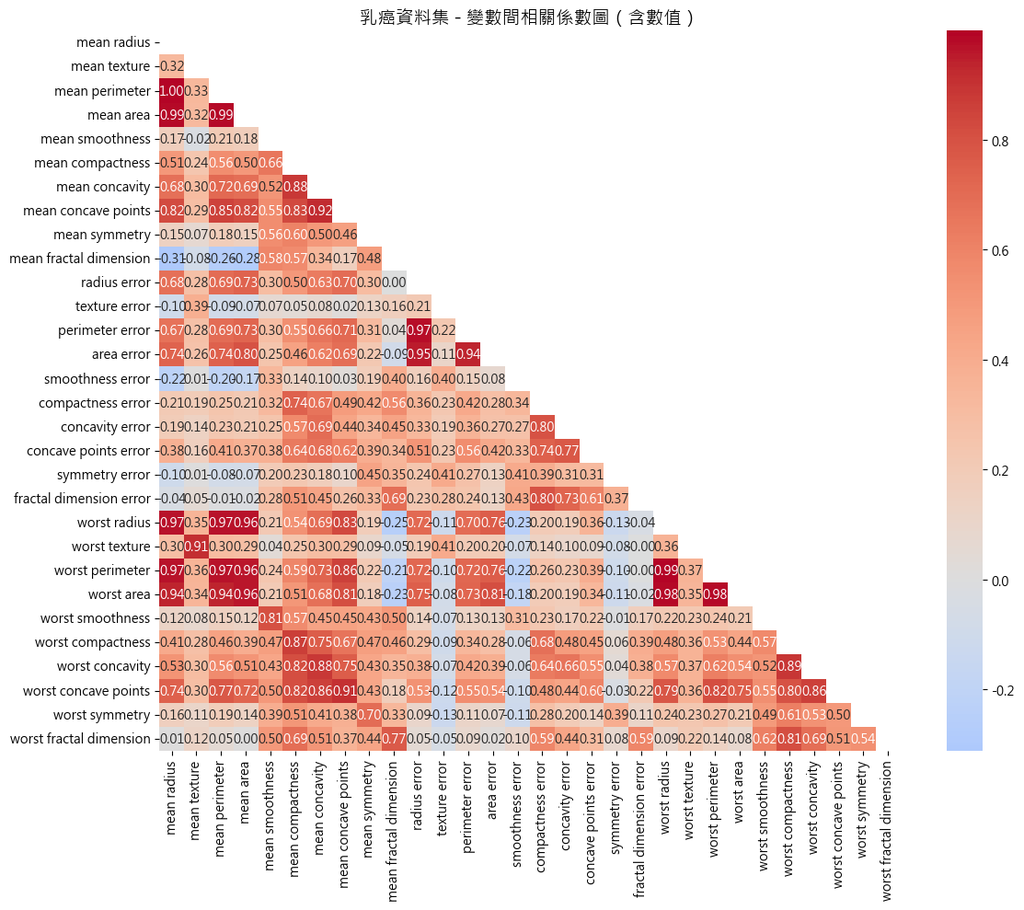

```python
corr_features = df_cancer.drop(['target'], axis=1)

corr_matrix = corr_features.corr()

plt.figure(figsize=(12, 10))
mask = np.triu(np.ones_like(corr_matrix, dtype=bool))
sns.heatmap(corr_matrix, annot=True, fmt=".2f", mask=mask, cmap='coolwarm', center=0)

plt.title('乳癌資料集 - 變數間相關係數圖（含數值）', fontsize=14)
plt.tight_layout()
plt.show()
```

觀察與討論

從相關係數圖中可以觀察到以下幾個重點：

> 強烈正相關：

> > 「mean radius」、「mean perimeter」、「mean area」之間有非常強的正相關，相關係數接近 0.99，顯示這些變數彼此高度線性關聯，推測它們可能描述了腫瘤的大小與外觀範圍。  
> > 這三個變數與「worst radius」、「worst perimeter」、「worst area」也有相當高的正相關，呈現出類似的關聯性。

> 中度正相關：

> > 「mean concave points」與「mean concavity」、「mean compactness」呈現中等以上的正相關（大約 0.8 左右），這些變數可能都與腫瘤邊界的形狀和凹陷程度有關。

> 弱或負相關：

> > 「fractal dimension error」與多數變數之間呈現較低或接近於 0 的相關，表示它的獨立性較高，可能帶有額外的資訊。  
> > 「mean fractal dimension」與「mean radius」的相關性為負值，說明腫瘤的邊界複雜度與其尺寸存在一定程度的負相關。

> 整體來看，資料中部分變數間具有高相關性，這代表在後續進行主成分分析（PCA）或模型建立時，有可能透過降維來簡化變數結構，同時保留大部分資訊。圖中也顯示出部分變數的資訊重複度較高。

3.繪製一張含每個化學成分（變數）的盒鬚圖（Boxplot），觀察每個變數的 scaling，作為是否標準化的參考。

程式碼主要功能  
針對乳癌資料集（Breast Cancer Dataset）進行資料標準化前後的分佈比較。具體流程如下：

> 載入資料：使用 load_breast_cancer() 從 sklearn 套件中載入乳癌影像量測資料，並將其轉換為 DataFrame 格式。

> 資料標準化：利用 StandardScaler() 對資料進行標準化處理，將所有變數轉換為平均值為 0、標準差為 1 的標準常態分佈，並存回 DataFrame。

> 繪製 Boxplot：
> - 第一張圖（左圖）展示原始資料的 boxplot，可以觀察到各變數間的尺度差異及分佈情況。
> - 第二張圖（右圖）展示標準化後資料的 boxplot，讓各變數在相同尺度下觀察分佈與異常值。

> 視覺化比較：透過兩個 boxplot 圖，直觀呈現標準化前後資料在尺度與分佈上的差異，幫助判斷是否需要進行標準化處理。

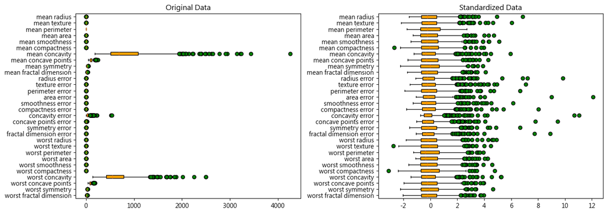

```python
cancer = load_breast_cancer()
df_cancer = pd.DataFrame(cancer.data, columns=cancer.feature_names)

scaler = StandardScaler()
df_scaled = pd.DataFrame(scaler.fit_transform(df_cancer), columns=df_cancer.columns)

fig, axes = plt.subplots(1, 2, figsize=(14, 5))

axes[0].boxplot(df_cancer, vert=False, patch_artist=True,
                boxprops=dict(facecolor='orange', linestyle='--'),
                flierprops=dict(marker='o', markerfacecolor='green'))
axes[0].set_yticklabels(df_cancer.columns[::-1])
axes[0].set_title('Original Data')

axes[1].boxplot(df_scaled, vert=False, patch_artist=True,
                boxprops=dict(facecolor='orange', linestyle='--'),
                flierprops=dict(marker='o', markerfacecolor='green'))
axes[1].set_yticklabels(df_scaled.columns[::-1])
axes[1].set_title('Standardized Data')

plt.tight_layout()
plt.show()
```

觀察與討論 從上圖可以觀察到以下幾點：

> 原始資料（左圖）：

> 標準化後資料（右圖）：

> > 經過標準化處理後，所有變數的尺度已被轉換至相同的標準（平均值為 0，標準差為 1），分佈也更接近於正態分佈。  
> > 此時各變數的 boxplot 變得相對一致，更容易比較變數之間的離群值、分佈範圍與變異情況。  
> > 可以清楚看出，部分變數（如 worst concavity 和 mean concavity）仍存在較多的離群值。

> 結論

> > 資料在進行 PCA 或其他機器學習分析前，確實有標準化的必要，避免因變數量級差異過大而影響模型表現與解釋能力。  
> > 標準化有助於後續資料分析時，讓所有變數在同一尺度下進行合理比較。

4.進行主成分分析，繪製特徵值由大而小的分佈，如 scree plot 與累積百分比的 pareto plot。

程式碼主要功能  
透過「Scree Plot」與「Pareto Plot」視覺化 PCA 的結果，幫助判斷適合保留的主成分數量。詳細功能如下：

> 資料前處理：

> > 從資料集中移除 target 欄位，僅保留特徵變數作為 PCA 的輸入。  
> > 將特徵資料進行標準化，確保各變數在同一尺度下進行主成分分析。

> PCA 分析：

> > 使用 PCA 模型擷取所有主成分，並計算每個主成分對應的特徵值與累積解釋變異量。

> 視覺化：
> - 左圖為 Scree Plot，以折線圖呈現特徵值隨主成分數量的遞減趨勢，用來判斷「轉折點」與適合的降維數量。
> - 右圖為 Pareto Plot，以直條圖結合折線圖，顯示每個主成分的特徵值及其累積解釋變異百分比，輔助判斷應保留多少主成分以涵蓋資料的主要變異。

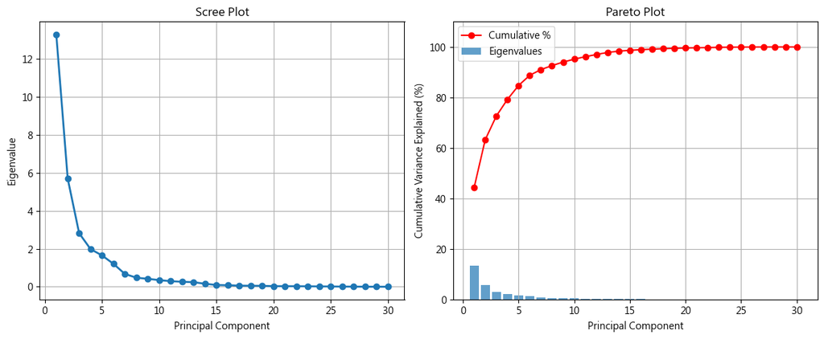

```python
df_cancer['target'] = cancer.target

X = df_cancer.drop('target', axis=1)

scaler = StandardScaler()
X_scaled = scaler.fit_transform(X)

pca = PCA()
pca.fit(X_scaled)

eigenvalues = pca.explained_variance_
cumulative_variance = np.cumsum(pca.explained_variance_ratio_) * 100

fig, axes = plt.subplots(1, 2, figsize=(12, 5))

axes[0].plot(range(1, len(eigenvalues) + 1), eigenvalues, marker='o', linestyle='-', linewidth=2)
axes[0].set_xlabel('Principal Component')
axes[0].set_ylabel('Eigenvalue')
axes[0].set_title('Scree Plot')
axes[0].grid(True)

axes[1].bar(range(1, len(eigenvalues) + 1), eigenvalues, alpha=0.7, label='Eigenvalues')
axes[1].plot(range(1, len(cumulative_variance) + 1), cumulative_variance, 'r-o', label='Cumulative %')
axes[1].set_ylabel('Cumulative Variance Explained (%)')
axes[1].set_xlabel('Principal Component')
axes[1].set_ylim([0, 110])
axes[1].set_title('Pareto Plot')
axes[1].legend()
axes[1].grid(True)

plt.tight_layout()
plt.show()
```

觀察與討論 根據上述產生的圖表，有以下觀察與結論：

> Scree Plot ：

> > 圖中可以看出前兩個主成分的特徵值明顯較大，分別約為 13 和 5.7，顯示其對資料的解釋能力相對較高。  
> > 隨著主成分數量增加，特徵值迅速下降，第 3 個主成分起後，特徵值皆小於 3，並呈現逐漸平緩的趨勢，後面的主成分對資料變異的貢獻較小。

> Pareto Plot：

> 結論

> > 資料的資訊主要集中在少數幾個主成分中，具有明顯的降維潛力，可考慮僅保留前 2 至 5 個主成分，達成資料簡化與有效保留變異的平衡。這也意味著後續的資料可視化或建模中，可能無需使用全部 30 個特徵。

5.每筆資料都有標籤值（label），代表腫瘤的成分（Malignant（惡性腫瘤）或 Benign（良性腫瘤））。假設先不看這項標籤。利用主成分分析取得前兩項成分，並繪製其散佈圖。是否可以從兩個主成分的散佈圖中看出兩個群組？請注意：資料是否先做標準化可能會影響結果，試著觀察「做與不做」標準化的差別。

程式碼主要功能

比較未標準化與標準化後資料在主成分分析（PCA）下的分布情形。

> 讀取 sklearn.datasets 中的乳癌資料集，並將其轉換為 pandas DataFrame 格式，將 target 欄位分別存成 X（特徵變數）與 y（目標變數）。  
> 針對未標準化資料與標準化資料（使用 StandardScaler）各自進行 PCA，取前兩個主成分 (Z1 與 Z2)。  
> 透過 matplotlib，將兩種處理下的 PCA 結果以散佈圖方式繪製於同一張圖的左右兩側，方便對照比較，觀察標準化對 PCA 結果分佈的影響。

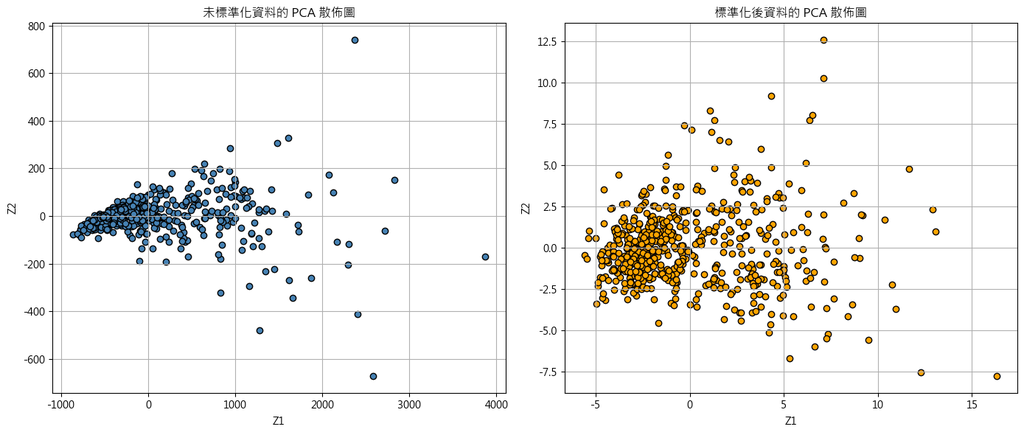

```python
cancer = load_breast_cancer()
df_cancer = pd.DataFrame(cancer.data, columns=cancer.feature_names)
df_cancer['target'] = cancer.target

X = df_cancer.drop('target', axis=1)
y = df_cancer['target']

pca = PCA(n_components=2)
X_pca_original = pca.fit_transform(X)

scaler = StandardScaler()
X_scaled = scaler.fit_transform(X)
pca_scaled = PCA(n_components=2)
X_pca_scaled = pca_scaled.fit_transform(X_scaled)

fig, axes = plt.subplots(1, 2, figsize=(14, 6))

axes[0].scatter(X_pca_original[:, 0], X_pca_original[:, 1], c='steelblue', edgecolors='k')
axes[0].set_xlabel('Z1')
axes[0].set_ylabel('Z2')
axes[0].set_title('未標準化資料的 PCA 散佈圖')
axes[0].grid(True)

axes[1].scatter(X_pca_scaled[:, 0], X_pca_scaled[:, 1], color='orange', edgecolors='k')
axes[1].set_xlabel('Z1')
axes[1].set_ylabel('Z2')
axes[1].set_title('標準化後資料的 PCA 散佈圖')
axes[1].grid(True)

plt.tight_layout()
plt.show()
```

觀察與討論

根據上述產生的圖表，有以下觀察與結論：

> 未標準化資料的 PCA（左圖）：

> > 資料分佈呈現強烈的延展性，Z1 軸的數值範圍極大（從約 -1000 到超過 3500）。  
> > 由於特徵值的單位與尺度不同，導致部分變數的變異大幅主導了主成分，使資料在散佈圖上看起來不均勻，集中於圖左下角，且分群效果不明顯。  
> > 這樣的結果難以直接從圖形辨識群組的分界。

> 標準化後資料的 PCA（右圖）：

> > 資料在標準化後，Z1 和 Z2 的尺度被統一（皆以標準差為單位），散佈範圍較為收斂且均勻分布。  
> > 資料點的分布較為擴散，能明顯看出兩個主成分所描述的變異結構，有助於後續進行分群或分類的視覺化判斷。  
> > 標準化後的結果顯示，資料間的變數尺度差異被消除，有助於 PCA 有效地保留多個特徵的資訊。

> 結論

> > 透過這兩張圖可以清楚看出，標準化資料後進行 PCA 更有利於資料結構的呈現與後續分析。  
> > 未標準化的 PCA 容易被少數尺度較大的變數主導，標準化處理是多變量分析的關鍵步驟之一。

6.再依據每筆資料的標籤，在散佈圖上塗上不同顏色

程式碼主要功能

程式碼的主要功能為：

> 1.載入乳癌資料集並將資料轉換為 DataFrame，包含 30 個特徵變數與目標變數。  
> 2.將資料拆分為特徵變數 X 和標籤變數 y（0 代表 Malignant 惡性腫瘤，1 代表 Benign 良性腫瘤）。  
> 3.分別對未標準化資料與標準化資料（使用標準化）進行主成分分析（PCA），並提取前兩個主成分 Z1 和 Z2。  
> 4.使用散佈圖繪製兩張圖：
> - 左圖：未標準化資料的 PCA 投影散佈圖，依據 target 變數以不同顏色標示資料點。
> - 右圖：標準化後資料的 PCA 投影散佈圖，同樣依據 target 變數以不同顏色區分。

> 觀察資料標準化對 PCA 結果的影響，能明顯看到兩個腫瘤類別在降維後的分佈差異。

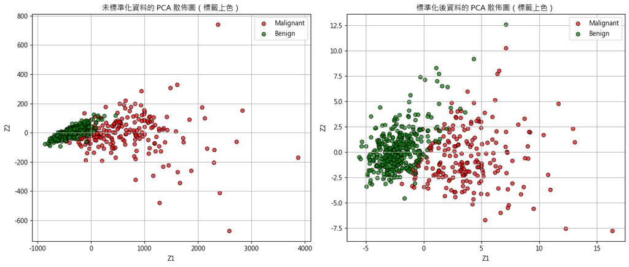

```python
cancer = load_breast_cancer()
df_cancer = pd.DataFrame(cancer.data, columns=cancer.feature_names)
df_cancer['target'] = cancer.target

X = df_cancer.drop('target', axis=1)
y = df_cancer['target']

pca = PCA(n_components=2)
X_pca_original = pca.fit_transform(X)

scaler = StandardScaler()
X_scaled = scaler.fit_transform(X)
pca_scaled = PCA(n_components=2)
X_pca_scaled = pca_scaled.fit_transform(X_scaled)

colors = {0: 'red', 1: 'green'}
labels_dict = {0: 'Malignant', 1: 'Benign'}

fig, axes = plt.subplots(1, 2, figsize=(14, 6))

for label in [0, 1]:
    axes[0].scatter(
        X_pca_original[y == label, 0],
        X_pca_original[y == label, 1],
        c=colors[label],
        label=labels_dict[label],
        edgecolors='k',
        alpha=0.7
    )
axes[0].set_xlabel('Z1')
axes[0].set_ylabel('Z2')
axes[0].set_title('未標準化資料的 PCA 散佈圖（標籤上色）')
axes[0].legend()
axes[0].grid(True)


for label in [0, 1]:
    axes[1].scatter(
        X_pca_scaled[y == label, 0],
        X_pca_scaled[y == label, 1],
        c=colors[label],
        label=labels_dict[label],
        edgecolors='k',
        alpha=0.7
    )
axes[1].set_xlabel('Z1')
axes[1].set_ylabel('Z2')
axes[1].set_title('標準化後資料的 PCA 散佈圖（標籤上色）')
axes[1].legend()
axes[1].grid(True)

plt.tight_layout()
plt.show()
```

觀察與討論

從上述兩張散佈圖的觀察結果如下：

> 在未標準化的 PCA 散佈圖中（左圖）

> > 雖然資料點可大致分成兩群，但分群效果並不明顯，且資料分佈呈現不對稱，Z1 軸上的尺度範圍過大，導致部分資料點彼此間的距離過於擴張或壓縮，難以清楚分辨 Malignant（惡性）與 Benign（良性）兩個類別。

> 標準化後的 PCA 散佈圖（右圖）

> > 改善了上述問題。經標準化處理後，Z1 與 Z2 軸的尺度更為平衡，兩類資料點之間的群聚效果也較為清晰，Benign（綠色）與 Malignant（紅色）大致呈現兩個相對分離的區塊，顯示出標準化有助於提升 PCA 視覺化的效果與分群可解釋性。

> 結論

> > 資料標準化前後對於 PCA 結果有明顯影響，標準化後的 PCA 散佈圖能更有效地顯示兩個腫瘤類別的潛在分群結構，未來在進行 PCA 於不同尺度特徵資料時，應優先考慮標準化處理。

7.如果採三個主成分，則可繪製立體圖。觀察立體圖是否比標準化後的PCA散布圖具備更好的群組分辨能力。請嘗試旋轉立體圖的角度以取得最好的辨別視野。

程式碼主要功能

程式碼的主要功能為：使用主成分分析（PCA）將標準化後的乳癌資料降維至三個主成分，並透過兩個不同的觀察角度繪製 3D 散佈圖（scatter plot），以視覺化 Benign（良性）與 Malignant（惡性）兩個腫瘤類別的分布情形。

> 1.使用 PCA 將資料降為三個主成分 (Z1, Z2, Z3)。  
> 2.使用 matplotlib 的 3D 繪圖功能，在同一張圖中建立兩個子圖（subplot），分別呈現兩個不同視角下的 3D 散佈圖。  
> 3.以紅色和綠色分別標示惡性（Malignant）與良性（Benign）腫瘤資料點，並加上邊框與透明度設定，方便區分。  
> 4.每個子圖以不同的 elev（仰角）與 azim（方位角）參數調整觀察視角，讓使用者能從不同角度更清楚地觀察群組間的分佈差異。  
> 5.圖表中添加座標軸標籤、圖例與標題，最後透過 plt.tight_layout() 自動調整版面配置並顯示圖表。

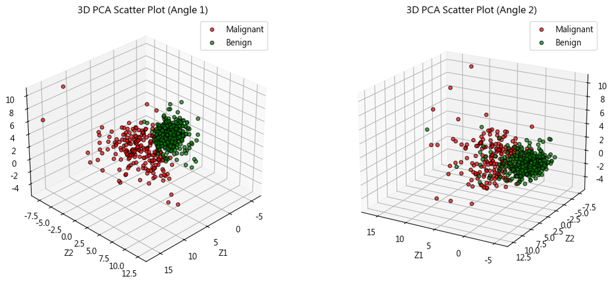

```python
pca_3d = PCA(n_components=3)
X_pca_3d = pca_3d.fit_transform(X_scaled)

fig = plt.figure(figsize=(12, 5))

ax1 = fig.add_subplot(1, 2, 1, projection='3d')
for label in [0, 1]:
    ax1.scatter(
        X_pca_3d[y == label, 0],
        X_pca_3d[y == label, 1],
        X_pca_3d[y == label, 2],
        c=colors[label],
        label=labels_dict[label],
        edgecolors='k',
        alpha=0.7
    )
ax1.set_title('3D PCA Scatter Plot (Angle 1)')
ax1.set_xlabel('Z1')
ax1.set_ylabel('Z2')
ax1.set_zlabel('Z3')
ax1.view_init(elev=30, azim=45)
ax1.legend()

ax2 = fig.add_subplot(1, 2, 2, projection='3d')
for label in [0, 1]:
    ax2.scatter(
        X_pca_3d[y == label, 0],
        X_pca_3d[y == label, 1],
        X_pca_3d[y == label, 2],
        c=colors[label],
        label=labels_dict[label],
        edgecolors='k',
        alpha=0.7
    )
ax2.set_title('3D PCA Scatter Plot (Angle 2)')
ax2.set_xlabel('Z1')
ax2.set_ylabel('Z2')
ax2.set_zlabel('Z3')
ax2.view_init(elev=20, azim=120)
ax2.legend()

plt.tight_layout()
plt.show()
```

觀察與討論

從上述兩張散佈圖的觀察結果如下：

> 從這兩個不同角度的 3D PCA 散佈圖中可以觀察到，將資料降維至三個主成分後，Malignant（惡性腫瘤）與 Benign（良性腫瘤）兩類資料在三維空間中呈現出更明顯的分群趨勢。

> 在第一個角度（Angle 1）下，可以清楚地看到 Benign 類別（綠色）大多集中在右上方，呈現相對緊密的聚集，而 Malignant 類別（紅色）則分布較為分散並集中在左下方。

> 綜合觀察兩個視角，使用三個主成分的立體圖，確實比二維平面散佈圖更有助於辨識惡性與良性腫瘤的分群結果。這也暗示著第三個主成分 Z3 在群組判別上提供了額外的資訊。

8.Z1 與 Z2 都是從原變數組合而成的新變數，可否從 Z1 與 Z2 的組成係數（即前兩個 eigenvector 的值），看出原變數哪個比較重要？哪個比較不重要？若再與原變數間的相關係數圖對照，是否透露相同的訊息。先不管理論怎麼說，就只是談談你的觀察與猜測。（譬如可以畫 eigenvectors 與變數對應的 heatmap）。

程式碼主要功能

> 1.使用 StandardScaler() 對原始資料進行標準化處理，確保各變數具有相同的尺度。  
> 2.執行主成分分析（PCA），提取資料中的前兩個主成分（Z1 和 Z2）。  
> 3.將前兩個主成分的 eigenvectors轉換為 DataFrame，方便後續視覺化。  
> 4.繪製一張 heatmap，用來展示前兩個主成分（Z1 & Z2）與原始 30 個變數之間的組成係數，觀察各變數在主成分中的貢獻程度，並以色彩強度呈現正負相關性。

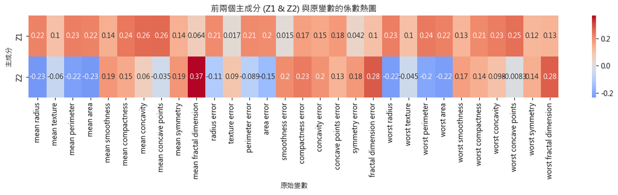

```python
cancer = load_breast_cancer()
df_cancer = pd.DataFrame(cancer.data, columns=cancer.feature_names)

scaler = StandardScaler()
X_scaled = scaler.fit_transform(df_cancer)

pca = PCA(n_components=2)
pca.fit(X_scaled)

eigenvectors = pd.DataFrame(
    pca.components_,
    columns=df_cancer.columns,
    index=['Z1', 'Z2']
)


plt.figure(figsize=(14, 4))
sns.heatmap(eigenvectors, annot=True, cmap='coolwarm', center=0)
plt.title('前兩個主成分 (Z1 & Z2) 與原變數的係數熱圖')
plt.xlabel('原始變數')
plt.ylabel('主成分')
plt.tight_layout()
plt.show()
```

觀察與討論

根據熱圖可以觀察到以下幾個重點：

> Z1 的特徵權重：Z1 與大部分變數呈現正相關，尤其是與 mean concavity、mean concave points、worst concavity、worst area、worst radius 等變數的係數較高，顯示這些變數在第一主成分 Z1 中具有較大的影響力。

> Z2 的特徵權重：Z2 則與部分變數呈現負相關，例如 mean perimeter、mean area、worst radius 等，特別是 mean fractal dimension 與 Z2 呈現強烈的正相關（0.37），說明此變數在第二主成分中扮演了重要角色。

> 重要性對比：從熱圖可見，Z1 整體的正相關變數較多，且相關程度較平均；而 Z2 主要依賴少數變數（如 mean fractal dimension 和 worst fractal dimension）的貢獻度較大。

> 對應到相關係數圖：若回頭參考原本的變數間相關係數圖，可以發現這些在 Z1 和 Z2 中權重高的變數，原本在資料中的變數間也展現出較強的相關性。例如 mean concavity 和 worst concavity 等變數彼此高度相關，且同時對 Z1 有較高貢獻。